# Final Exam

Andrea Astudillo

2024-12-09

```r
library(readr)
library(fpp)
library(fpp2)
library(TTR)
```

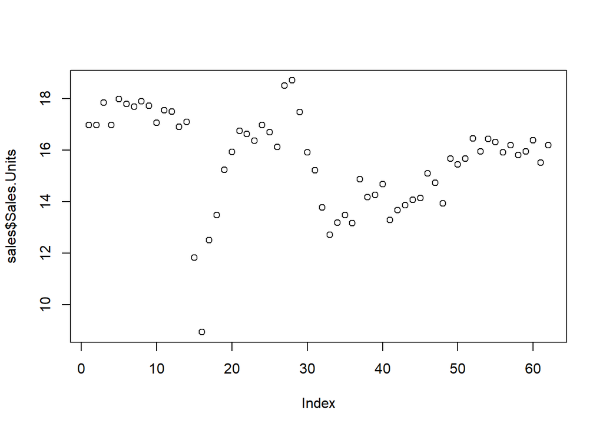

```r
sales = read.csv(file.choose())
plot(sales$Sales.Units)
```

#Summary of Import Data -The first step before forecasting is to import the data. We can observe below that the data needs to be converted to times series in order to compare the different forecast methods.

#Plot and Inference #Show a time series plot.

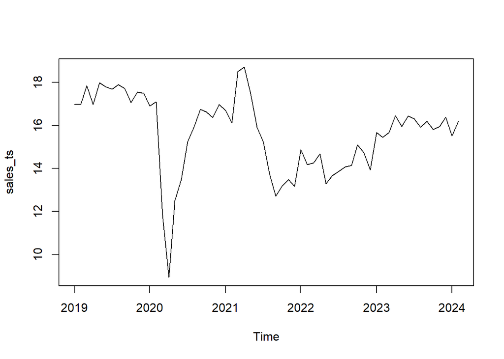

```r
sales_data = sales$Sales.Units
sales_ts = ts(sales_data, frequency = 12, start = c(2019, 1))
plot(sales_ts)
```

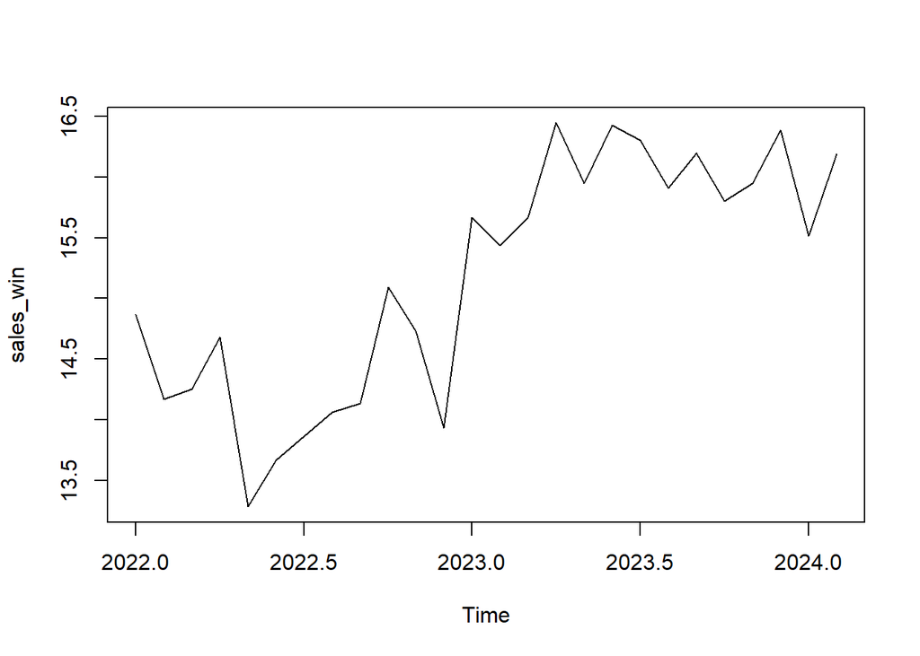

```r
sales_win = window(sales_ts, frequency = 12, start = c(2022, 1))
plot(sales_win)
```

#Central Tendency #What are the min, max, mean, median, 1st, and 3rd Quartile values of the times series?

```r
summary(sales_win)
```

```
##    Min. 1st Qu.  Median    Mean 3rd Qu.    Max.
##   13.29   14.19   15.47   15.18   15.95   16.45
```

#Show the box plot.

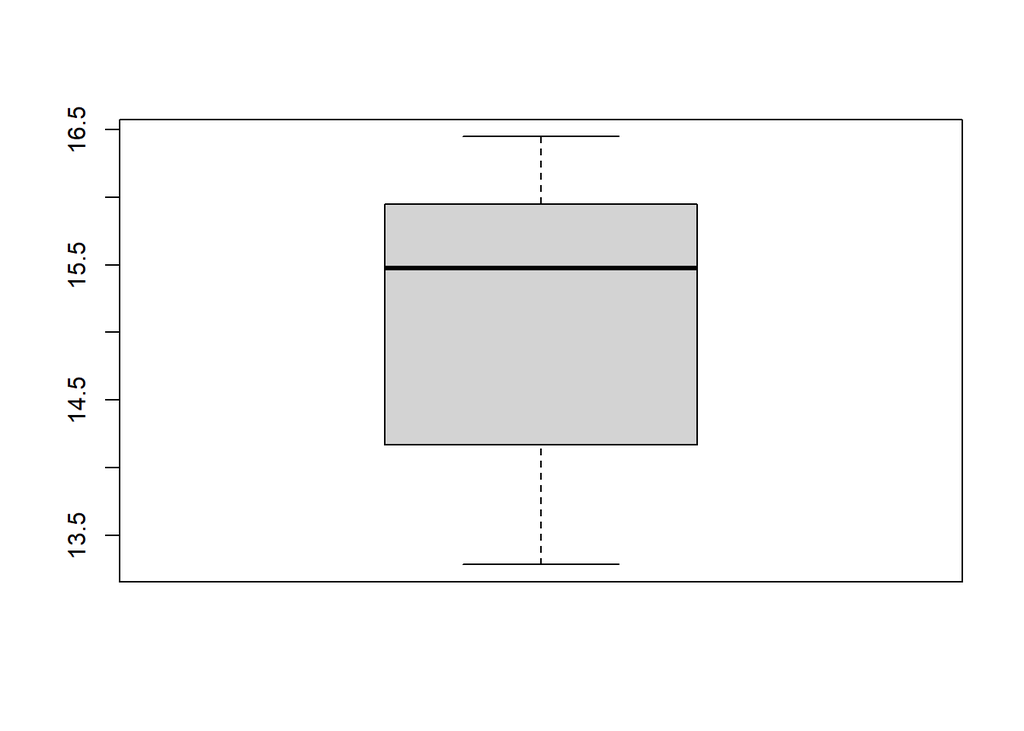

```r
boxplot(sales_win)
```

#Can you summarize your observation about the time series from the summary stats and box plot? -In the summary results we can observe that the median is higher than the mean indicating the distribution is left skewed. In the box plot, we can observe there are no outliers and confirm its left skewed distribution.

#Decompostion

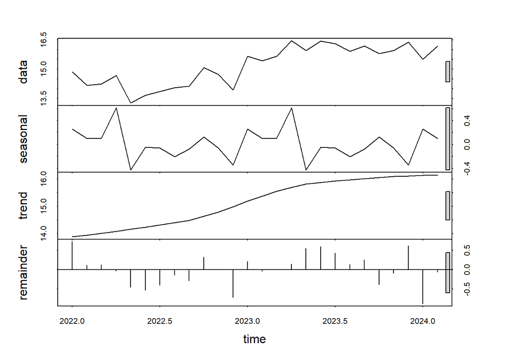

```r
stl_decom = stl(sales_win,s.window = "periodic")
plot(stl_decom)
```

#Is the time series seasonal?

```r
decomp = decompose(sales_win)
decomp
```

```
## $x
##         Jan    Feb    Mar    Apr    May    Jun    Jul    Aug    Sep    Oct
## 2022 14.866 14.168 14.253 14.681 13.286 13.669 13.867 14.064 14.136 15.091
## 2023 15.665 15.434 15.668 16.446 15.948 16.428 16.302 15.909 16.193 15.799
## 2024 15.513 16.191
##         Nov    Dec
## 2022 14.733 13.935
## 2023 15.945 16.386
## 2024
##
## $seasonal
##              Jan         Feb         Mar         Apr         May         Jun
## 2022  0.37197569 -0.03735764  0.03405903  0.69685069  0.11885069  0.44622569
## 2023  0.37197569 -0.03735764  0.03405903  0.69685069  0.11885069  0.44622569
## 2024  0.37197569 -0.03735764
##              Jul         Aug         Sep         Oct         Nov         Dec
## 2022 -0.12229514 -0.27592014 -0.39777431  0.42472569 -0.11773264 -1.14160764
## 2023 -0.12229514 -0.27592014 -0.39777431  0.42472569 -0.11773264 -1.14160764
## 2024
##
## $trend
##           Jan      Feb      Mar      Apr      May      Jun      Jul      Aug
## 2022       NA       NA       NA       NA       NA       NA 14.26237 14.34842
## 2023 15.21937 15.39771 15.56029 15.67550 15.75550 15.90812 16.00392 16.02913
## 2024       NA       NA
##           Sep      Oct      Nov      Dec
## 2022 14.46012 14.59262 14.77708 15.00296
## 2023       NA       NA       NA       NA
## 2024
##
## $random
##               Jan          Feb          Mar          Apr          May
## 2022           NA           NA           NA           NA           NA
## 2023  0.073649306  0.073649306  0.073649306  0.073649306  0.073649306
## 2024           NA           NA
##               Jun          Jul          Aug          Sep          Oct
## 2022           NA -0.273079861 -0.008496528  0.073649306  0.073649306
## 2023  0.073649306  0.420378472  0.155795139           NA           NA
## 2024
##               Nov          Dec
## 2022  0.073649306  0.073649306
## 2023           NA           NA
## 2024
##
## $figure
##  [1]  0.37197569 -0.03735764  0.03405903  0.69685069  0.11885069  0.44622569
##  [7] -0.12229514 -0.27592014 -0.39777431  0.42472569 -0.11773264 -1.14160764
##
## $type
## [1] "additive"
##
## attr(,"class")
## [1] "decomposed.ts"
```

-Yes the time series is seasonal and can be observe in the decomposition results which includes seasonal, trend and random.

#Is the decomposition additive or multiplicative? -The decomposition is additive. Implying that seasonal fluctuations are constant over time.

#If seasonal, what are the values of the seasonal monthly indices?

```r
decomp$figure
```

```
##  [1]  0.37197569 -0.03735764  0.03405903  0.69685069  0.11885069  0.44622569
##  [7] -0.12229514 -0.27592014 -0.39777431  0.42472569 -0.11773264 -1.14160764
```

#For which month is the time series value high, and for which month is it low? -The month with the lowest value in the time series is December and the one with the highest value is April.

#Can you think of the reason behind the high and low values in those months? -In the month of December, usually families prefer to stay at home due to the cold weather. Also as the holidays approaches families gather together at home and tend to go out less lowering the car’s sales. Meanwhile, in the month of April is where the warm weather starts and families go out more often, therefore increasing the need of a car.

#Show the plot for time series adjusted for seasonality. Overlay this with the line fluctuals? Does seasonality have big fluctuations in the value of time series?

```r
seasadj(stl_decom)
```

```
##           Jan      Feb      Mar      Apr      May      Jun      Jul      Aug
## 2022 14.60933 14.07036 14.14442 14.06487 13.71182 13.71235 13.92337 14.26812
## 2023 15.40833 15.33636 15.55942 15.82987 16.37382 16.47135 16.35837 16.11312
## 2024 15.25633 16.09336
##           Sep      Oct      Nov      Dec
## 2022 14.21187 14.96423 14.79010 14.27815
## 2023 16.26887 15.67223 16.00210 16.72915
## 2024
```

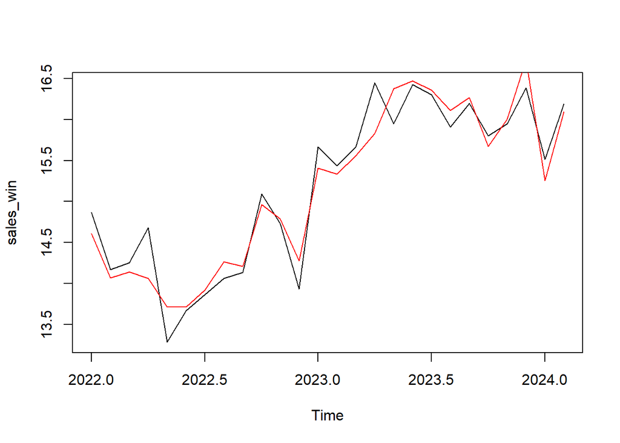

```r
plot(sales_win)
stl_decom = stl(sales_win,s.window = "periodic")
lines(seasadj(stl_decom), col="red")
```

-The seasonality has some fluctuations over the value of the time series. For example, mid 2022 the value of the time series is increasing while the seasonality value is constant with no peaks in demand.

#Naïve Method #Output

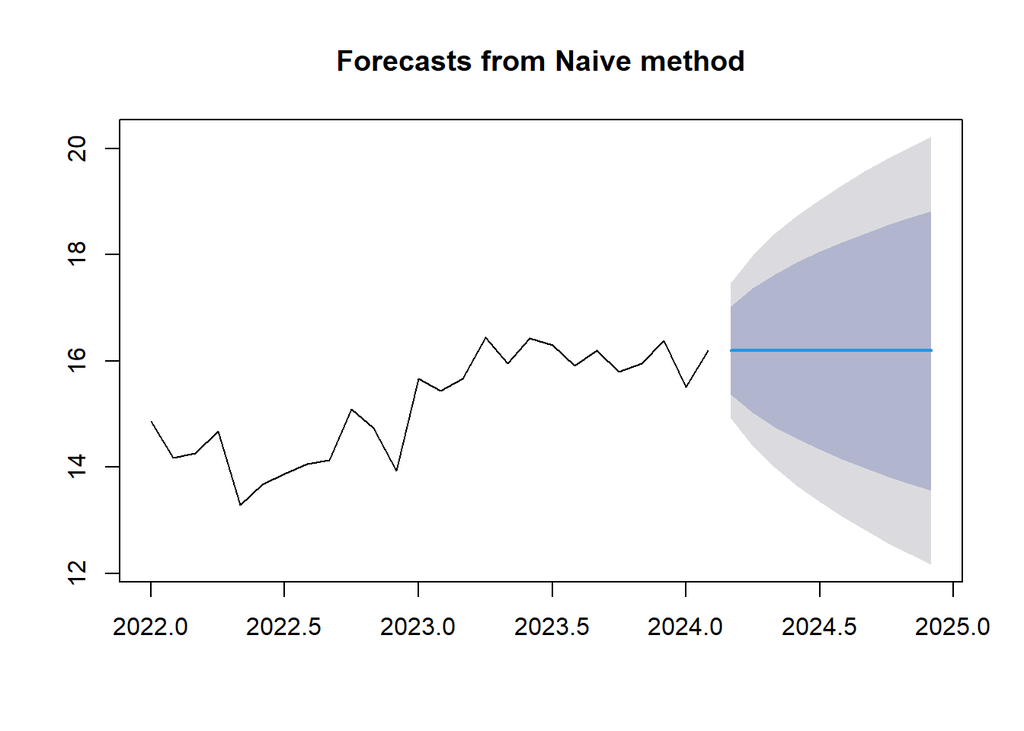

```r
naive_sales = naive(sales_win)
plot(naive_sales)
```

#Perform Residual Analysis for this technique. #Do a plot of residuals. What does the plot indicate?

```r
attributes(naive_sales)
```

```
## $names
##  [1] "method"    "model"     "lambda"    "x"         "fitted"    "residuals"
##  [7] "series"    "mean"      "level"     "lower"     "upper"
##
## $class
## [1] "forecast"
```

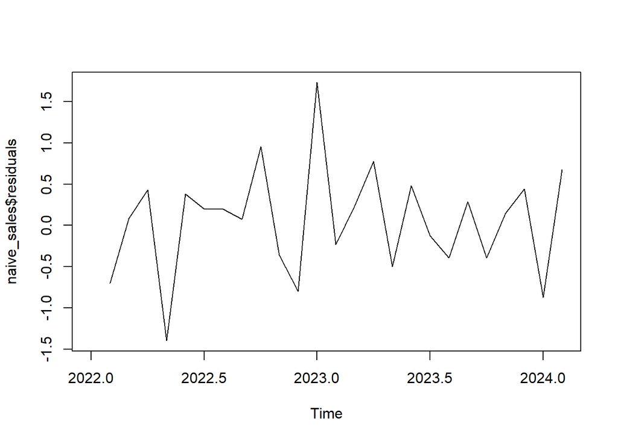

```r
plot(naive_sales$residuals)
```

-After plotting the residuals of the naive forecast we can observe there is some pattern in the plot. Ideally, the residual plot should have a random residual plot.

#Do a Histogram plot of residuals. What does the plot indicate?

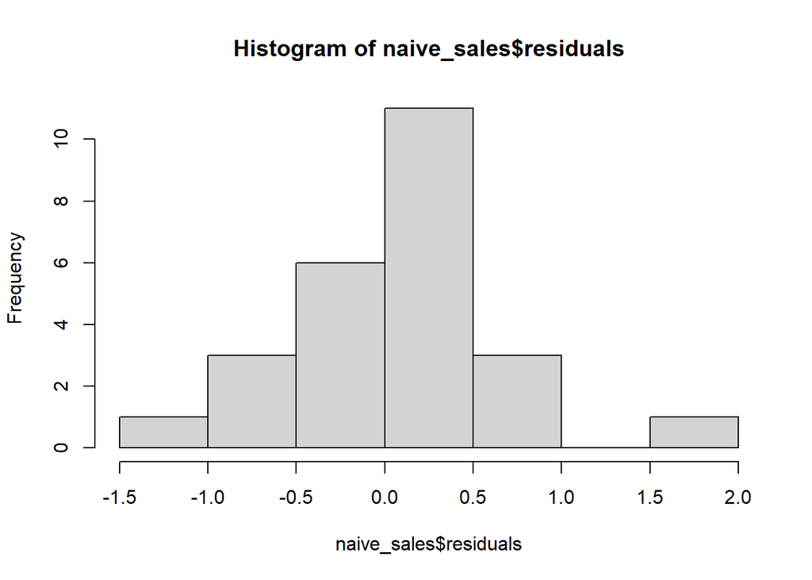

```r
hist(naive_sales$residuals)
```

-After plotting the residuals of the naive forecast, the histogram seems to be normally distributed.

#Do a plot of fitted values vs. residuals. What does the plot indicate?

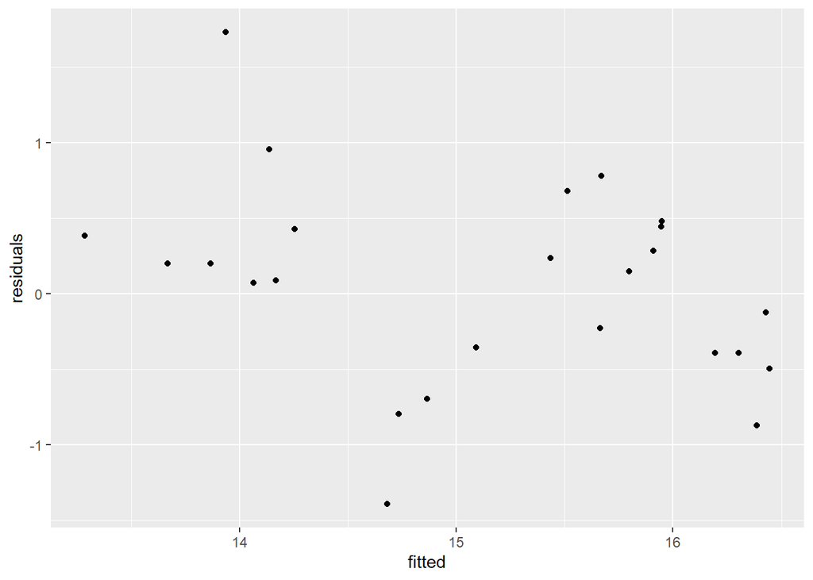

```r
library(ggplot2)
plot_naive = data.frame(fitted=naive_sales$fitted, residuals=naive_sales$residuals, actual=sales_win)
ggplot(plot_naive, aes(x=fitted, y=residuals))+geom_point()
```

-Ideally the scatter plot between the fitted and residuals should not have any patterns. The fitted values should have zero effect on the residual values. However this plot shows that the fitted values have effect on the residual values.

#Do a plot of actual values vs. residuals. What does the plot indicate?

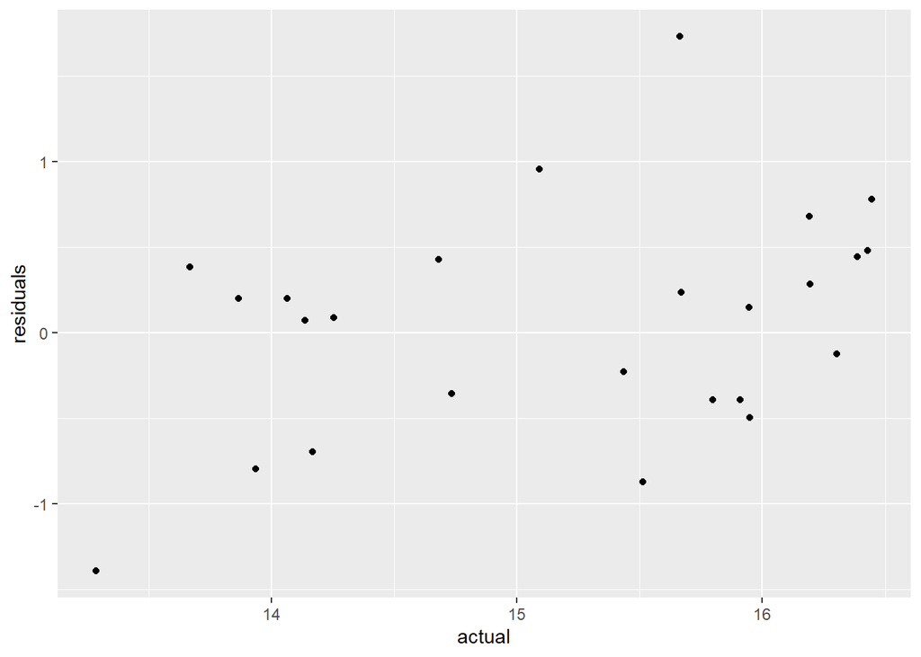

```r
ggplot(plot_naive, aes(x=actual, y=residuals))+geom_point()
```

-Similar to the previous plot, it shows that the actual values have effect on the residual values.

#Do an ACF plot of the residuals? What does this plot indicate?

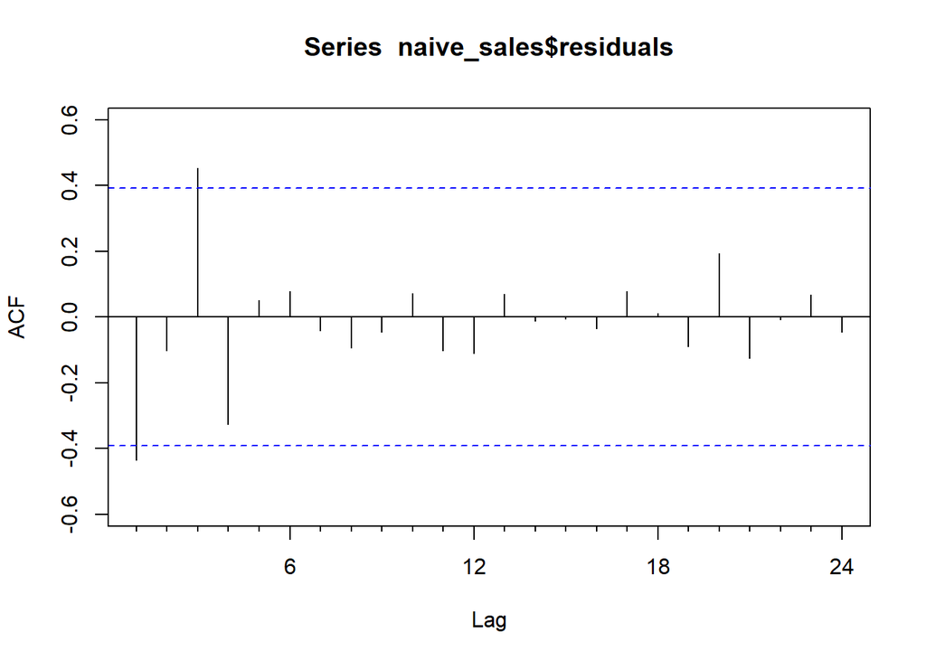

```r
Acf(naive_sales$residuals)
```

-In the Acf plot we can observe that some values have cross the confidence level indicating some data was not taken into account in the naive forecast.

#Print the five measures of accuracy for this forecasting technique

```r
naive_accuracy = accuracy(naive_sales)
naive_accuracy
```

```
##                 ME      RMSE     MAE       MPE     MAPE      MASE       ACF1
## Training set 0.053 0.6498938 0.51412 0.2460432 3.411387 0.3230122 -0.4356982
```

#Forecast #Time series value for next year. Show table and plot

```r
forecast_naive = forecast(naive_sales,12)
forecast_naive
```

```
##          Point Forecast    Lo 80    Hi 80    Lo 95    Hi 95
## Mar 2024         16.191 15.35813 17.02387 14.91723 17.46477
## Apr 2024         16.191 15.01314 17.36886 14.38962 17.99238
## May 2024         16.191 14.74842 17.63358 13.98477 18.39723
## Jun 2024         16.191 14.52526 17.85674 13.64346 18.73854
## Jul 2024         16.191 14.32864 18.05336 13.34277 19.03923
## Aug 2024         16.191 14.15089 18.23111 13.07092 19.31108
## Sep 2024         16.191 13.98743 18.39457 12.82093 19.56107
## Oct 2024         16.191 13.83528 18.54672 12.58824 19.79376
## Nov 2024         16.191 13.69238 18.68962 12.36969 20.01231
## Dec 2024         16.191 13.55723 18.82477 12.16299 20.21901
```

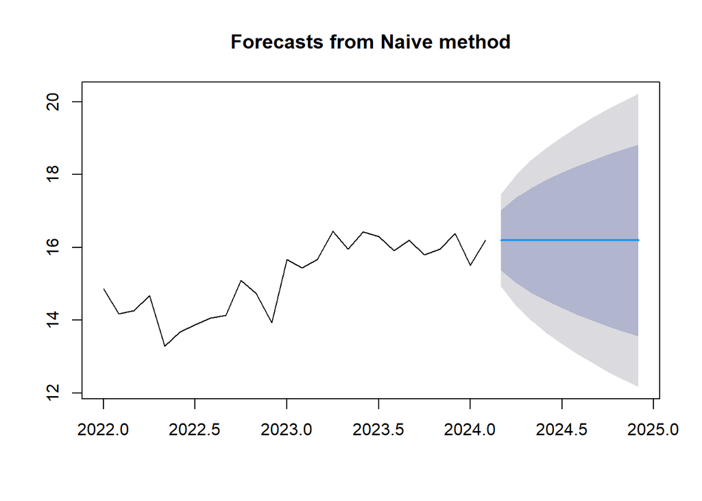

```r
plot(forecast_naive)
```

#Summarize this forecasting technique #How good is the accuracy?

#What does it predict the time series value will be in one year?

16.191 (in millions)

#Simple Moving Averages #Plot the graph for the time series. #Show the Simple Moving average of order three on the plot above in Red #Show the Simple Moving average of order six on the plot above in Blue #Show the Simple Moving average of order nine on the plot above in Green

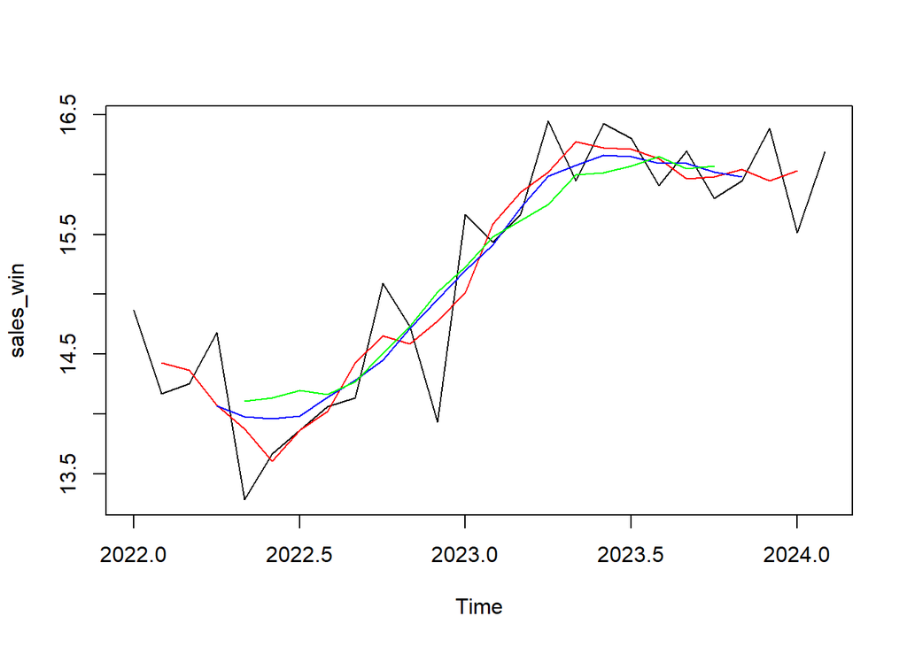

```r
mae3_sales = ma(sales_win,order = 3)
mae6_sales = ma(sales_win,order = 6)
mae9_sales = ma(sales_win,order = 9)
plot(sales_win)
lines(mae3_sales,col="red")
lines(mae6_sales,col="blue")
lines(mae9_sales,col="green")
```

#(Bonus) show the forecast for the next 12 months using one of the simple average orders that you feel works best for time series

```r
forecast_mae3 = forecast(mae3_sales, h=12)
forecast_mae3
```

```
##          Point Forecast    Lo 80    Hi 80    Lo 95    Hi 95
## Feb 2024       16.02999 15.73609 16.32390 15.58050 16.47948
## Mar 2024       16.02999 15.61437 16.44561 15.39435 16.66563
## Apr 2024       16.02999 15.52097 16.53902 15.25151 16.80848
## May 2024       16.02999 15.44223 16.61776 15.13108 16.92890
## Jun 2024       16.02999 15.37285 16.68713 15.02499 17.03500
## Jul 2024       16.02999 15.31014 16.74985 14.92907 17.13092
## Aug 2024       16.02999 15.25246 16.80752 14.84086 17.21912
## Sep 2024       16.02999 15.19878 16.86121 14.75876 17.30123
## Oct 2024       16.02999 15.14836 16.91163 14.68165 17.37834
## Nov 2024       16.02999 15.10067 16.95932 14.60871 17.45127
## Dec 2024       16.02999 15.05531 17.00467 14.53934 17.52064
## Jan 2025       16.02999 15.01197 17.04801 14.47306 17.58692
```

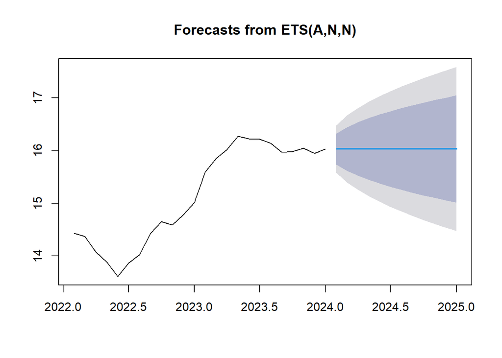

```r
plot(forecast_mae3)
```

#What are your observations of the plot as the moving average order goes up?

-After plotting the three different moving averages, we can observe the higher the order number the more smooth the lines its. The lower the moving average the closer it is to the actual values.

#Simple Smoothing #Perform a simple smoothing forecast for the next 12 months for the time series.

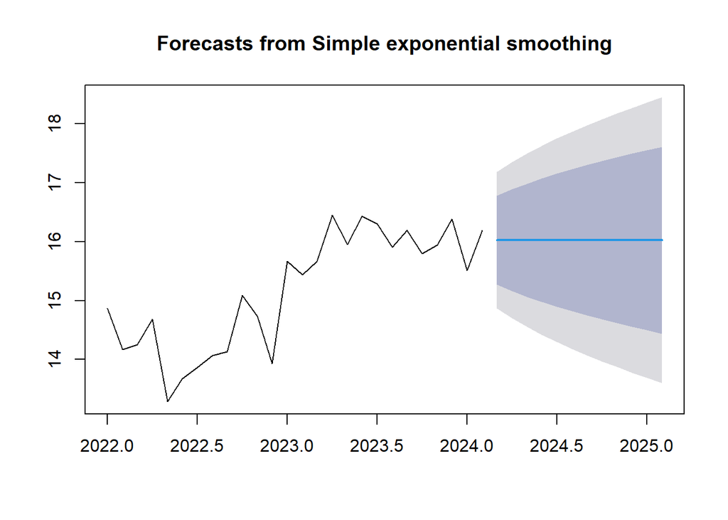

```r
ses_sales = ses(sales_win, 12)
plot(ses_sales)
```

#What is the value of alpha? What does that value signify?

```r
summary(ses_sales)
```

```
##
## Forecast method: Simple exponential smoothing
##
## Model Information:
## Simple exponential smoothing
##
## Call:
## ses(y = sales_win, h = 12)
##
##   Smoothing parameters:
##     alpha = 0.5558
##
##   Initial states:
##     l = 14.5655
##
##   sigma:  0.5893
##
##      AIC     AICc      BIC
## 61.13388 62.22479 64.90817
##
## Error measures:
##                     ME     RMSE       MAE      MPE     MAPE      MASE
## Training set 0.1009008 0.566215 0.4348547 0.555512 2.889828 0.2732112
##                    ACF1
## Training set -0.1227939
##
## Forecasts:
##          Point Forecast    Lo 80    Hi 80    Lo 95    Hi 95
## Mar 2024       16.02361 15.26835 16.77888 14.86854 17.17869
## Apr 2024       16.02361 15.15954 16.88769 14.70212 17.34510
## May 2024       16.02361 15.06297 16.98426 14.55444 17.49279
## Jun 2024       16.02361 14.97526 17.07196 14.42030 17.62693
## Jul 2024       16.02361 14.89434 17.15288 14.29655 17.75068
## Aug 2024       16.02361 14.81885 17.22837 14.18109 17.86614
## Sep 2024       16.02361 14.74781 17.29941 14.07245 17.97478
## Oct 2024       16.02361 14.68053 17.36669 13.96955 18.07768
## Nov 2024       16.02361 14.61646 17.43076 13.87156 18.17566
## Dec 2024       16.02361 14.55519 17.49204 13.77785 18.26938
## Jan 2025       16.02361 14.49637 17.55086 13.68789 18.35933
## Feb 2025       16.02361 14.43973 17.60750 13.60127 18.44595
```

-The value of alpha is 0.5558. When alpha value is not close to 1 gives more weight to more past values and less responsive to changes. In this case alpha is somewhere in the middle.

#What is the value of the initial state?

-14.5655

#What is the value of sigma? What does the sigma signify?

-The value of sigma is 0.5893. The higher the value of sigma the more variability and the less reliable the forecast it is. A lower value indicated the forecast errors tend to be smaller. In this case, it can be considered as moderate variability.

#Perform Residual Analysis for this technique. #Do a plot of residuals. What does the plot indicate?

```r
attributes(ses_sales)
```

```
## $names
##  [1] "model"     "mean"      "level"     "x"         "upper"     "lower"
##  [7] "fitted"    "method"    "series"    "residuals"
##
## $class
## [1] "forecast"
```

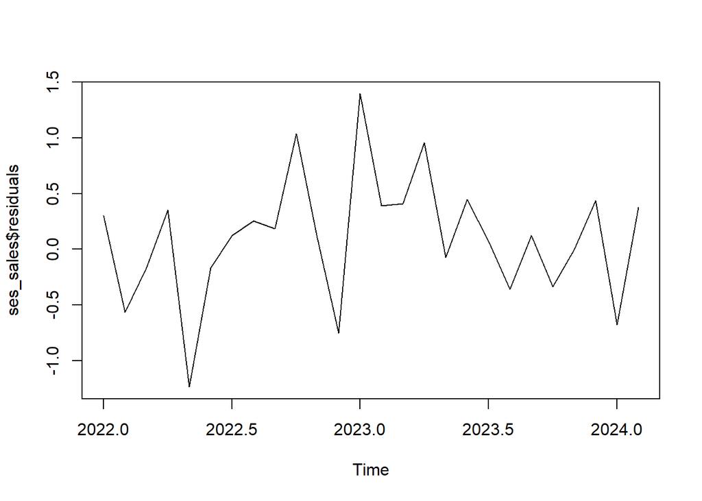

```r
plot(ses_sales$residuals)
```

-In the simple exponential smoothing residual plot, we can observe that is more random than the naive.

#Do a Histogram plot of residuals. What does the plot indicate?

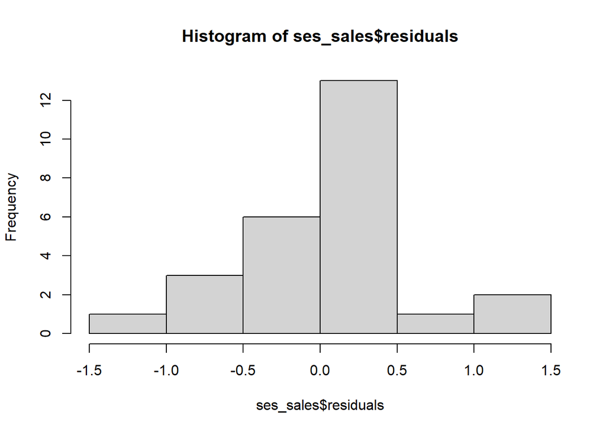

```r
hist(ses_sales$residuals)
```

#Do a plot of fitted values vs. residuals. What does the plot indicate?

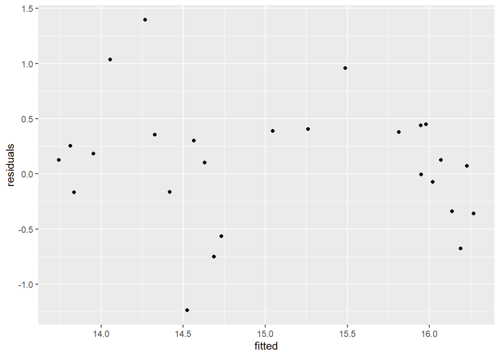

```r
plot_ses = data.frame(fitted=ses_sales$fitted, residuals=ses_sales$residuals, actual=sales_win)
ggplot(plot_ses, aes(x=fitted, y=residuals))+geom_point()
```

-Ideally the scatter plot between the fitted and residuals should not have any pattern. The fitted values should have zero effect on the residual values. However this plot shows that the fitted values have effect on the residual values.

#Do a plot of actual values vs. residuals. What does the plot indicate?

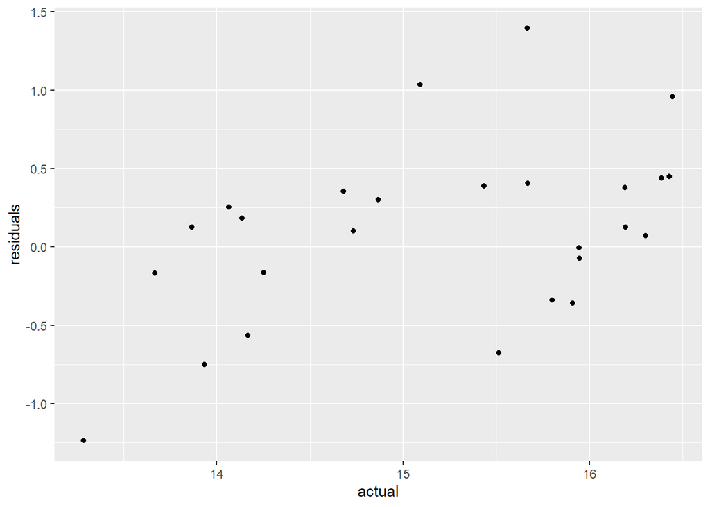

```r
ggplot(plot_ses, aes(x=actual, y=residuals))+geom_point()
```

-Ishows that the actual values have effect on the residual values. Ideally the scatter plot should not have any pattern.

#Do an ACF plot of the residuals? What does this plot indicate?

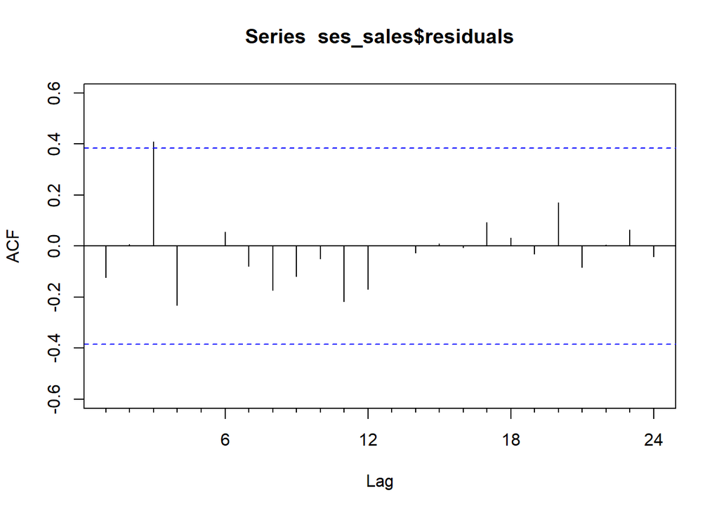

```r
Acf(ses_sales$residuals)
```

-In the Acf plot we can observe one value have cross the confidence interval indicating that not all data was not included in the forecast.

#Print the five measures of accuracy for this forecasting technique

```r
ses_accuracy = accuracy(ses_sales)
ses_accuracy
```

```
##                     ME     RMSE       MAE      MPE     MAPE      MASE
## Training set 0.1009008 0.566215 0.4348547 0.555512 2.889828 0.2732112
##                    ACF1
## Training set -0.1227939
```

#Forecast #Time series value for next year. Show table and plot

```r
forecast_ses = forecast(ses_sales, h=12)
forecast_ses
```

```
##          Point Forecast    Lo 80    Hi 80    Lo 95    Hi 95
## Mar 2024       16.02361 15.26835 16.77888 14.86854 17.17869
## Apr 2024       16.02361 15.15954 16.88769 14.70212 17.34510
## May 2024       16.02361 15.06297 16.98426 14.55444 17.49279
## Jun 2024       16.02361 14.97526 17.07196 14.42030 17.62693
## Jul 2024       16.02361 14.89434 17.15288 14.29655 17.75068
## Aug 2024       16.02361 14.81885 17.22837 14.18109 17.86614
## Sep 2024       16.02361 14.74781 17.29941 14.07245 17.97478
## Oct 2024       16.02361 14.68053 17.36669 13.96955 18.07768
## Nov 2024       16.02361 14.61646 17.43076 13.87156 18.17566
## Dec 2024       16.02361 14.55519 17.49204 13.77785 18.26938
## Jan 2025       16.02361 14.49637 17.55086 13.68789 18.35933
## Feb 2025       16.02361 14.43973 17.60750 13.60127 18.44595
```

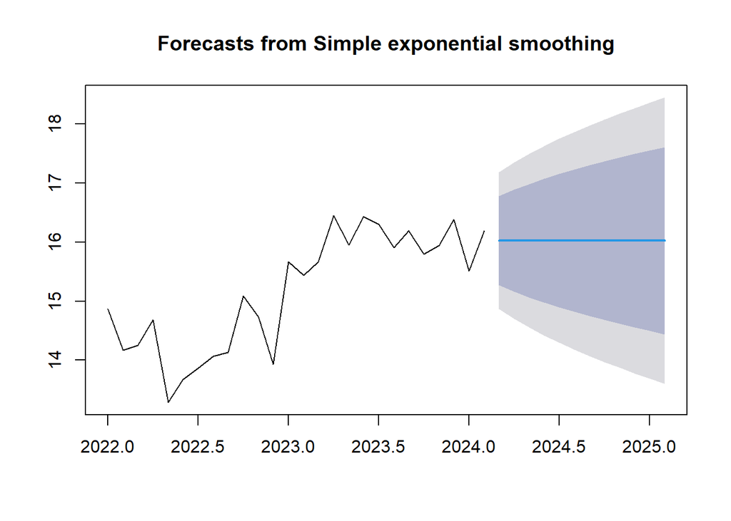

```r
plot(forecast_ses)
```

#Summarize this forecasting technique #How good is the accuracy?

-The model has an overall good accuracy with a low MAPE, MAE and MASE results.The MAPE has a good forecast error, indicating that only 2.88% of the predication are not accurate, performing better than the naive

#What does it predict the time series value will be in one year?

-16.02361 (in millions)

#Holt-Winters #Perform Holt-Winters forecast for the next 12 months for the time series.

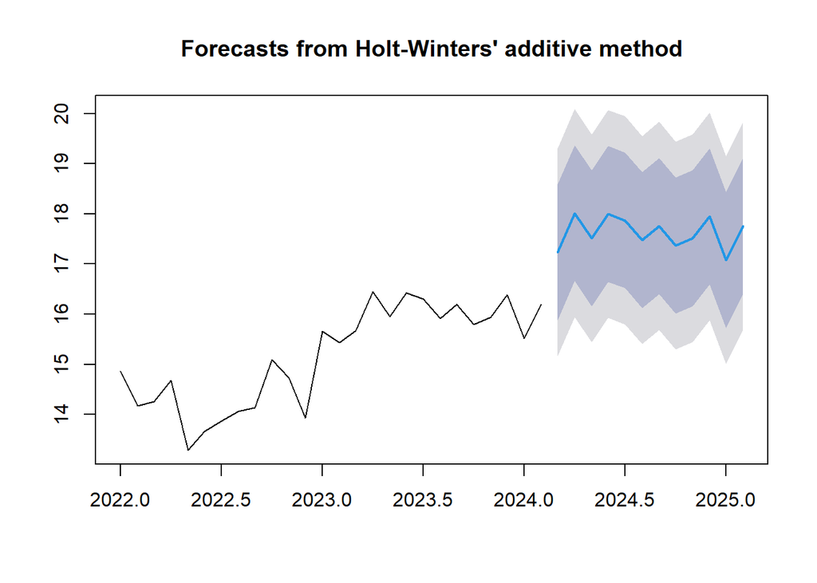

```r
hw_sales = hw(sales_win, h=12)
plot(hw_sales)
```

#What is the value of alpha? What does that value signify?

```r
summary(hw_sales)
```

```
##
## Forecast method: Holt-Winters' additive method
##
## Model Information:
## Holt-Winters' additive method
##
## Call:
## hw(y = sales_win, h = 12)
##
##   Smoothing parameters:
##     alpha = 2e-04
##     beta  = 2e-04
##     gamma = 0.9997
##
##   Initial states:
##     l = 13.424
##     b = 0.1305
##     s = -0.9951 -0.2147 0.5375 -0.7997 -0.2747 -0.8722
##            0.2528 -1.0152 0.5749 0.2429 0.6483 1.9153
##
##   sigma:  1.0571
##
##       AIC      AICc       BIC
##  96.75263 173.25263 118.14027
##
## Error measures:
##                       ME     RMSE       MAE        MPE     MAPE      MASE
## Training set -0.01760396 0.655559 0.5118556 -0.1586194 3.307403 0.3215895
##                   ACF1
## Training set 0.1938631
##
## Forecasts:
##          Point Forecast    Lo 80    Hi 80    Lo 95    Hi 95
## Mar 2024       17.23629 15.88162 18.59096 15.16450 19.30809
## Apr 2024       18.01447 16.65980 19.36914 15.94268 20.08626
## May 2024       17.51639 16.16172 18.87107 15.44460 19.58819
## Jun 2024       17.99612 16.64145 19.35080 15.92433 20.06792
## Jul 2024       17.86972 16.51505 19.22440 15.79792 19.94152
## Aug 2024       17.47630 16.12162 18.83097 15.40450 19.54809
## Sep 2024       17.75974 16.40506 19.11441 15.68794 19.83154
## Oct 2024       17.36545 16.01077 18.72013 15.29365 19.43725
## Nov 2024       17.51113 16.15645 18.86581 15.43932 19.58293
## Dec 2024       17.95157 16.59689 19.30626 15.87976 20.02338
## Jan 2025       17.07859 15.72390 18.43328 15.00678 19.15040
## Feb 2025       17.75657 16.40188 19.11126 15.68475 19.82839
```

The value of alpha is 0.0002. The alpha value is not close to 1, giving more weight to past values and less responsive to changes.

#What is the value of beta? What does that value signify?

-The value of alpha is 0.0002. The beta value controls the weight of the trend component, higher values gives more weight to recent observations. In this case, the beta value indicates the trend component remains constant over time.

#What is the value of gamma? What does that value signify?

-The value of gamma is 0.9997. The gamma values control the weight of the seasonal component, higher values gives weights to the more recent observations of the seasonality.

#What is the value of initial states for the level, trend, and seasonality? What do these values signify?

Initial states: l = 13.424 b = 0.1305 s = -0.9951 -0.2147 0.5375 -0.7997 -0.2747 -0.8722 0.2528 -1.0152 0.5749 0.2429 0.6483 1.9153

#What is the value of sigma? What does the sigma signify?

-The value of sigma is 1.0571. The higher the value of sigma the more variability and the less reliable the forecast it is.

#Perform Residual Analysis for this technique. #Do a plot of residuals. What does the plot indicate?

```r
attributes(hw_sales)
```

```
## $names
##  [1] "model"     "mean"      "level"     "x"         "upper"     "lower"
##  [7] "fitted"    "method"    "series"    "residuals"
##
## $class
## [1] "forecast"
```

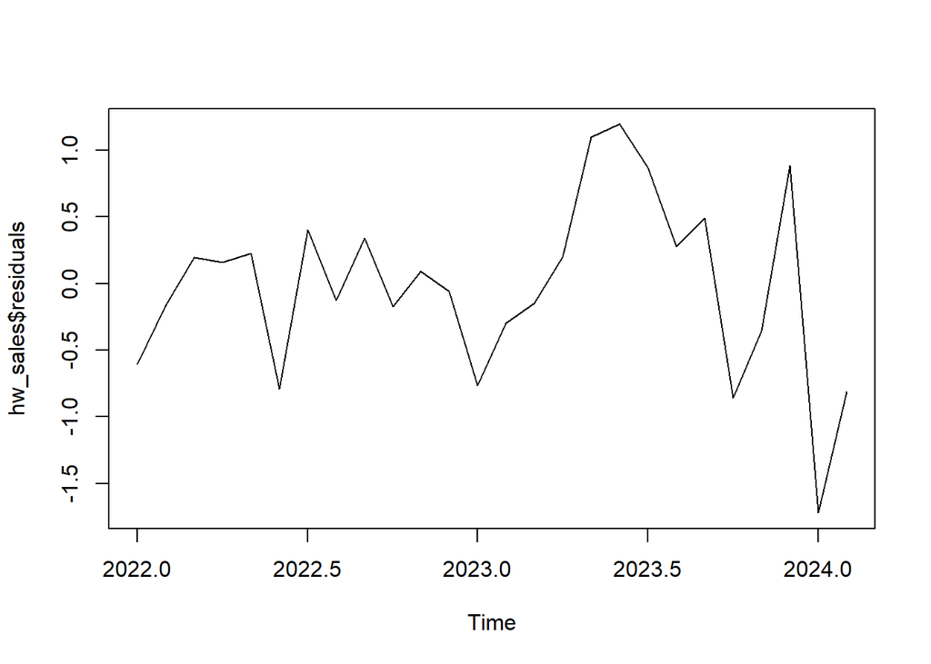

```r
plot(hw_sales$residuals)
```

-In the holt- winters residual plot, we can observe that is random than the naive and the exponential smoothing.

#Do a Histogram plot of residuals. What does the plot indicate?

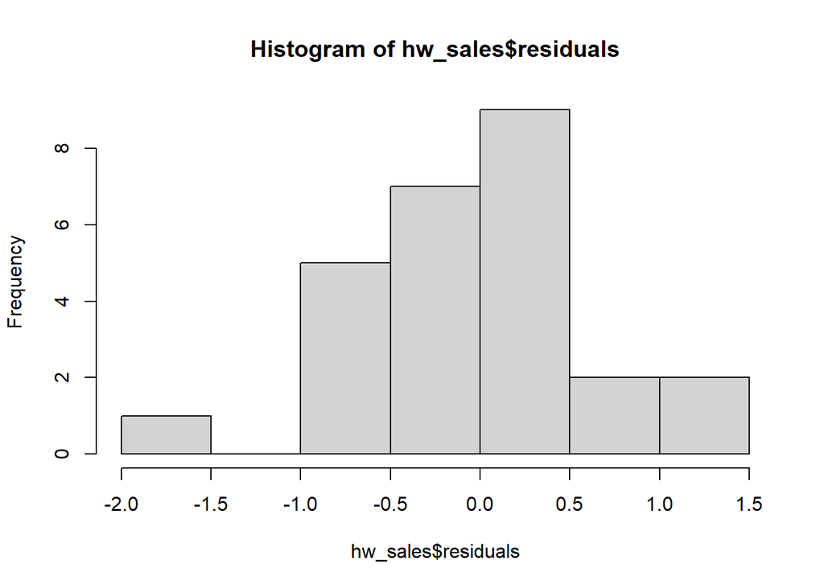

```r
hist(hw_sales$residuals)
```

-After plotting the residuals of the holt-winter forecast, the histogram its not normally distributed. Ideally most of the values should be at zero.

#Do a plot of fitted values vs. residuals. What does the plot indicate?

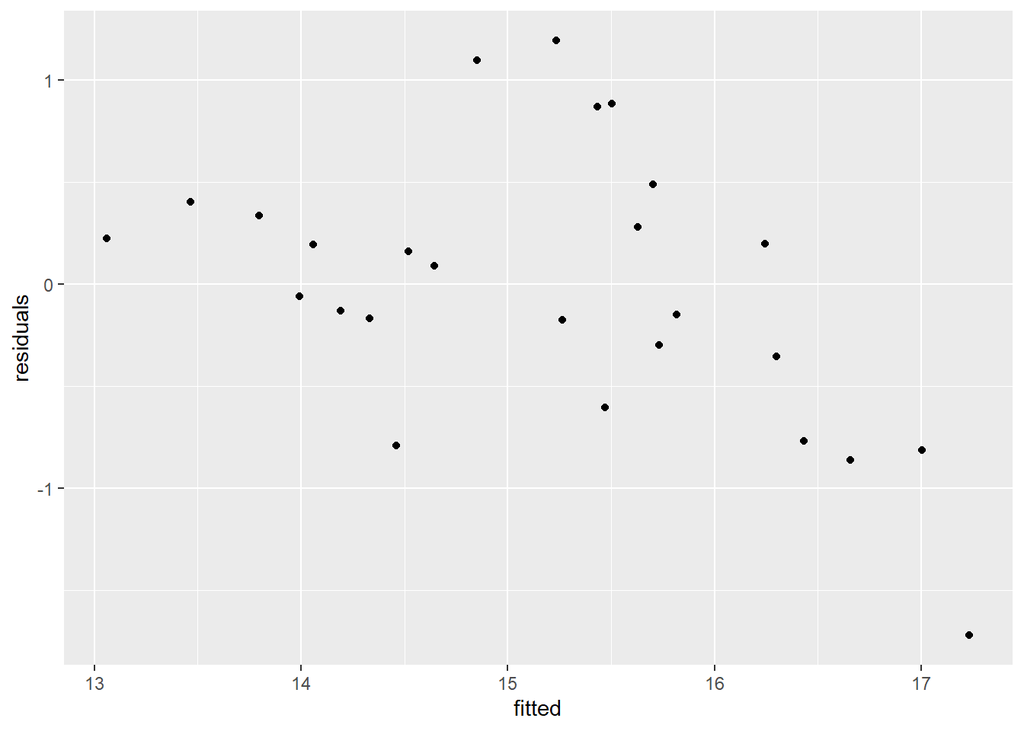

```r
plot_hw = data.frame(fitted=hw_sales$fitted, residuals=hw_sales$residuals, actual=sales_win)
ggplot(plot_hw, aes(x=fitted, y=residuals))+geom_point()
```

-Ideally the scatter plot between the fitted and residuals should not have any pattern. The fitted values should have zero effect on the residual values. However this plot shows that the fitted values have effect on the residual values.

#Do a plot of actual values vs. residuals. What does the plot indicate?

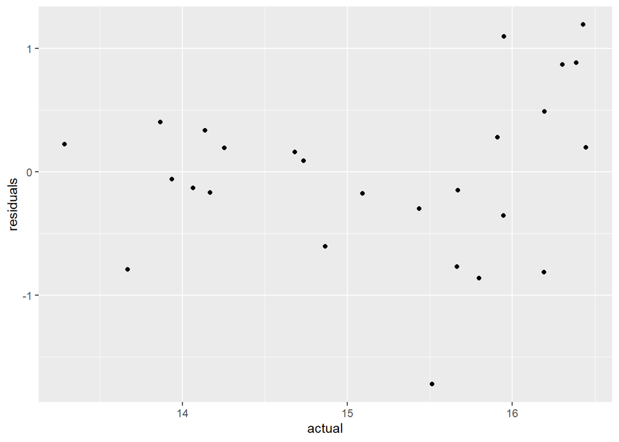

```r
ggplot(plot_hw, aes(x=actual, y=residuals))+geom_point()
```

-Similar to the previous plot, it shows that the actual values have effect on the residual values. Ideally the scatter plot should not have any pattern.

#Do an ACF plot of the residuals? What does this plot indicate?

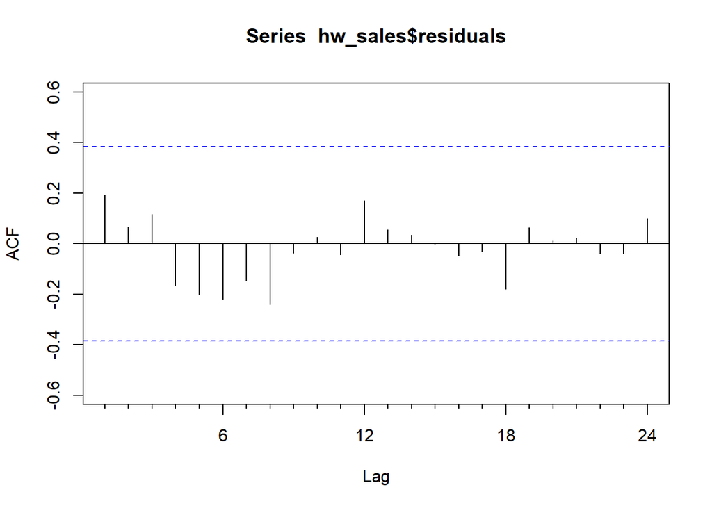

```r
Acf(hw_sales$residuals)
```

-We can observe that all the values in the Acf plot of the Holt- Winters have not cross the confidence interval.Meaning that all data was included in the forecast.

#Print the five measures of accuracy for this forecasting technique

```r
hw_accuracy = accuracy(hw_sales)
hw_accuracy
```

```
##                       ME     RMSE       MAE        MPE     MAPE      MASE
## Training set -0.01760396 0.655559 0.5118556 -0.1586194 3.307403 0.3215895
##                   ACF1
## Training set 0.1938631
```

#Forecast #Time series value for next year. Show table and plot

```r
forecast_hw = forecast(hw_sales, h=12)
forecast_hw
```

```
##          Point Forecast    Lo 80    Hi 80    Lo 95    Hi 95
## Mar 2024       17.23629 15.88162 18.59096 15.16450 19.30809
## Apr 2024       18.01447 16.65980 19.36914 15.94268 20.08626
## May 2024       17.51639 16.16172 18.87107 15.44460 19.58819
## Jun 2024       17.99612 16.64145 19.35080 15.92433 20.06792
## Jul 2024       17.86972 16.51505 19.22440 15.79792 19.94152
## Aug 2024       17.47630 16.12162 18.83097 15.40450 19.54809
## Sep 2024       17.75974 16.40506 19.11441 15.68794 19.83154
## Oct 2024       17.36545 16.01077 18.72013 15.29365 19.43725
## Nov 2024       17.51113 16.15645 18.86581 15.43932 19.58293
## Dec 2024       17.95157 16.59689 19.30626 15.87976 20.02338
## Jan 2025       17.07859 15.72390 18.43328 15.00678 19.15040
## Feb 2025       17.75657 16.40188 19.11126 15.68475 19.82839
```

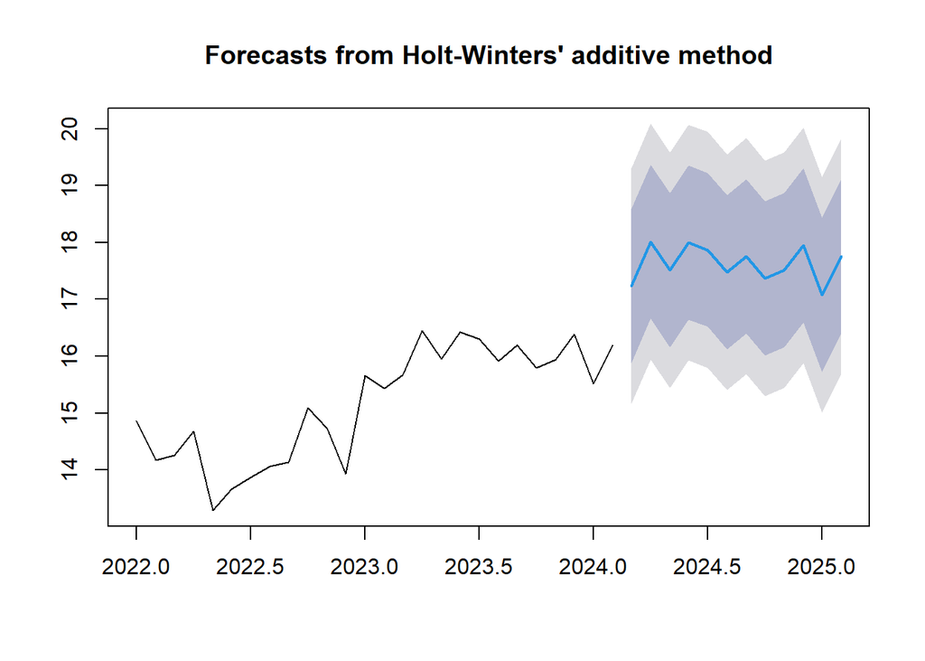

```r
plot(forecast_hw)
```

#Summarize this forecasting technique #How good is the accuracy?

-The model has an overall good accuracy with a low MAPE, MAE and MASE results.The MAPE has a good forecast error, indicating that only 3.30% of the predication are not accurate, performing better than the naive, but not than the simple exponential smoothing.

#What does it predict the time series value will be in one year?

Point Forecast Mar 2024 17.23629  
Apr 2024 18.01447  
May 2024 17.51639  
Jun 2024 17.99612  
Jul 2024 17.86972 Aug 2024 17.47630  
Sep 2024 17.75974  
Oct 2024 17.36545  
Nov 2024 17.51113  
Dec 2024 17.95157  
Jan 2025 17.07859  
Feb 2025 17.75657

#Arima #Is the time series data stationary? How did you verify?

```r
adf.test(sales_win)
```

```
##
##  Augmented Dickey-Fuller Test
##
## data:  sales_win
## Dickey-Fuller = -1.449, Lag order = 2, p-value = 0.7823
## alternative hypothesis: stationary
```

-The adf test results indicates the time series is non stationary as the p value is higher than 0.05.

#How many differences are needed to make it stationary?

```r
ndiffs(sales_win)
```

```
## [1] 1
```

```r
nsdiffs(sales_win)
```

```
## [1] 0
```

```r
sales_win_diff1 = diff(sales_win, differences = 1)
ndiffs(sales_win_diff1)
```

```
## [1] 0
```

```r
adf.test(sales_win_diff1)
```

```
##
##  Augmented Dickey-Fuller Test
##
## data:  sales_win_diff1
## Dickey-Fuller = -2.1759, Lag order = 2, p-value = 0.5054
## alternative hypothesis: stationary
```

```r
sales_win_diff2 = diff(sales_win, differences = 2)
ndiffs(sales_win_diff1)
```

```
## [1] 0
```

```r
adf.test(sales_win_diff2)
```

```
##
##  Augmented Dickey-Fuller Test
##
## data:  sales_win_diff2
## Dickey-Fuller = -4.7823, Lag order = 2, p-value = 0.01
## alternative hypothesis: stationary
```

#Is Seasonality component needed?

```r
Box.test(sales_win, lag = 12, type = "Ljung-Box")
```

```
##
##  Box-Ljung test
##
## data:  sales_win
## X-squared = 81.235, df = 12, p-value = 2.398e-12
```

#Plot the Time Series chart of the differenced series.

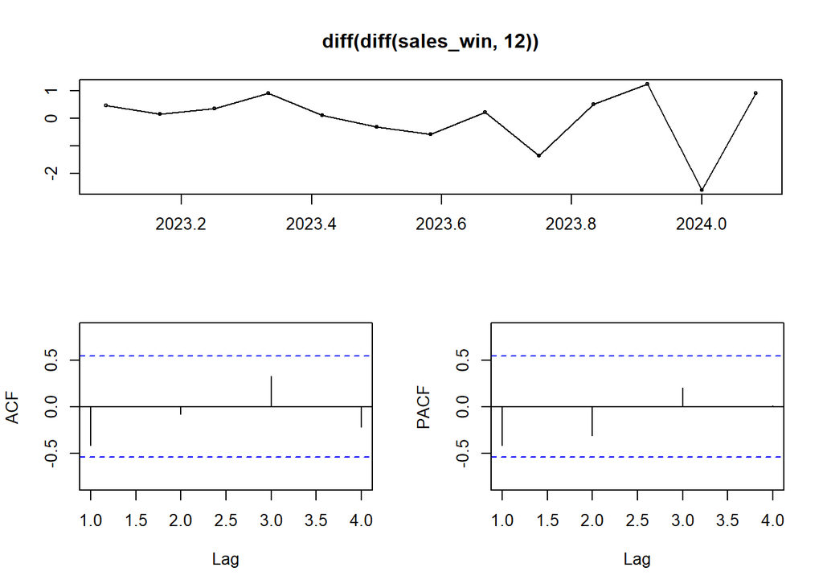

```r
tsdisplay(diff(diff(sales_win,12)))
```

#Plot the ACF and PACF plot of the differenced series.

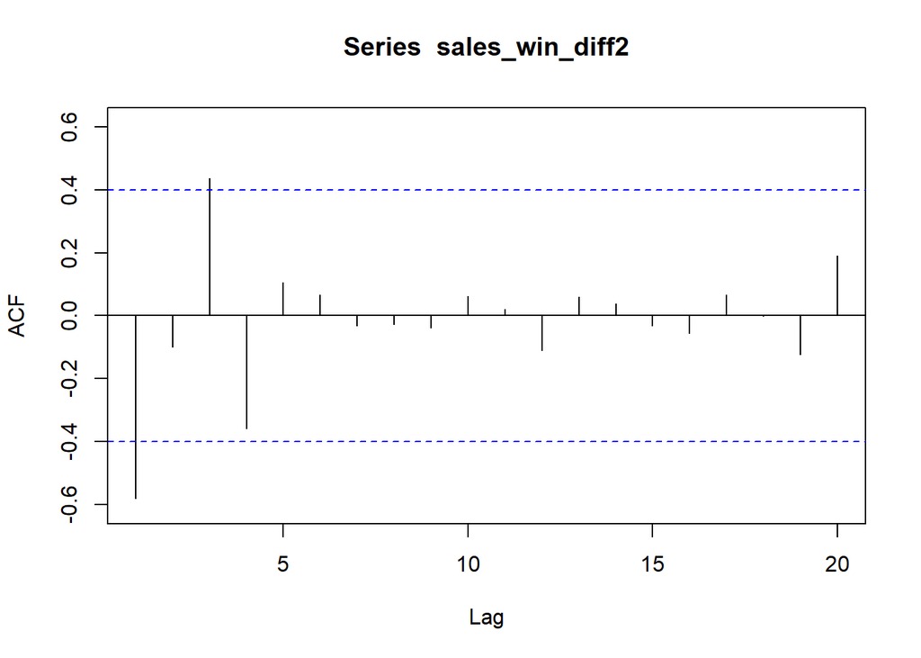

```r
Acf(sales_win_diff2, lag.max = 20)
```

```r
Acf(sales_win_diff2, lag.max = 20, plot = FALSE)
```

```
##
## Autocorrelations of series 'sales_win_diff2', by lag
##
##      0      1      2      3      4      5      6      7      8      9     10
##  1.000 -0.582 -0.100  0.437 -0.358  0.106  0.067 -0.033 -0.027 -0.039  0.062
##     11     12     13     14     15     16     17     18     19     20
##  0.019 -0.110  0.059  0.039 -0.032 -0.057  0.065  0.000 -0.123  0.191
```

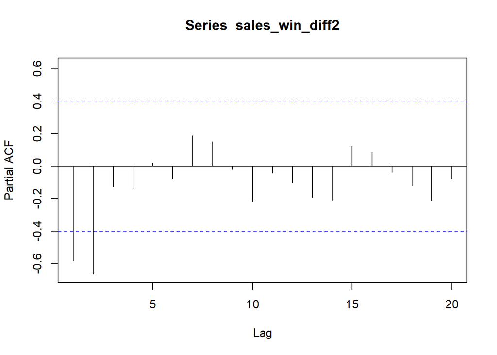

```r
Pacf(sales_win_diff2, lag.max = 20)
```

```r
Pacf(sales_win_diff2, lag.max = 20, plot = FALSE)
```

```
##
## Partial autocorrelations of series 'sales_win_diff2', by lag
##
##      1      2      3      4      5      6      7      8      9     10     11
## -0.582 -0.665 -0.128 -0.139  0.018 -0.078  0.187  0.150 -0.022 -0.216 -0.043
##     12     13     14     15     16     17     18     19     20
## -0.100 -0.194 -0.210  0.123  0.083 -0.040 -0.123 -0.212 -0.077
```

#Based on the ACF and PACF, which are the possible ARIMA model possible?